# Bootstrap Percentile Confidence Interval Problems

Alan T. Arnholt

Last updated: October 26, 2022 at 12:50:52 PM

# 1 Bootstrap Distributions

1. Construct a 94% bootstrap percentile confidence interval for the mean number of obstructive contacts (`oc`) in the `EPIDURAL` data set from the `PASWR2` package. Use a `for` loop and the `infer` pipeline to construct your confidence intervals.

```r
library(PASWR2)
library(tidyverse)
library(infer)
summary(EPIDURAL)
```

```
   doctor         kg               cm                ease
 Dr. A:23   Min.   : 48.00   Min.   :152.0   Difficult :20
 Dr. B:21   1st Qu.: 72.00   1st Qu.:160.0   Easy      :57
 Dr. C:21   Median : 84.00   Median :165.0   Impossible: 8
 Dr. D:20   Mean   : 86.08   Mean   :165.4
            3rd Qu.: 94.00   3rd Qu.:170.0
            Max.   :168.00   Max.   :185.0

               treatment        oc                            complications
 Hamstring Stretch  :35   Min.   : 0.000   Failure - person got dizzy: 1
 Traditional Sitting:50   1st Qu.: 0.000   Failure - too many OCs    : 2
                          Median : 1.000   None                      :76
                          Mean   : 1.286   Paresthesia               : 5
                          3rd Qu.: 2.000   Wet Tap                   : 1
                          Max.   :10.000
                          NA's   :1
```

```r
EPIDURALC <- na.omit(EPIDURAL) # removing the NA value
summary(EPIDURALC)
```

```
   doctor         kg               cm                ease
 Dr. A:23   Min.   : 48.00   Min.   :152.0   Difficult :20
 Dr. B:21   1st Qu.: 72.00   1st Qu.:160.0   Easy      :56
 Dr. C:20   Median : 84.50   Median :165.0   Impossible: 8
 Dr. D:20   Mean   : 86.21   Mean   :165.3
            3rd Qu.: 94.00   3rd Qu.:170.0
            Max.   :168.00   Max.   :185.0
               treatment        oc                            complications
 Hamstring Stretch  :35   Min.   : 0.000   Failure - person got dizzy: 0
 Traditional Sitting:49   1st Qu.: 0.000   Failure - too many OCs    : 2
                          Median : 1.000   None                      :76
                          Mean   : 1.286   Paresthesia               : 5
                          3rd Qu.: 2.000   Wet Tap                   : 1
                          Max.   :10.000
```

```r
B <- 10^4
bsm <- numeric(B)
for(i in 1:B){
  bss <- sample(EPIDURALC$oc, size = sum(!is.na(EPIDURALC$oc)), replace = TRUE)
  bsm[i] <- mean(bss)
}
(quantile(bsm, probs = c(0.03, 0.97)) -> BSPCI)
```

```
       3%       97%
0.9047619 1.7261905
```

```r
# Infer pipeline
EPIDURALC %>%
  specify(response = oc) %>%
  generate(reps = B, type = "bootstrap") %>%
  calculate(stat = "mean") -> bsmip
head(bsmip)
```

```
Response: oc (numeric)
# A tibble: 6 × 2
  replicate  stat
      <int> <dbl>
1         1  1.18
2         2  1.10
3         3  1.21
4         4  1.24
5         5  1.07
6         6  1.32
```

```r
(get_confidence_interval(bsmip, level = 0.94) -> CI1)
```

```
# A tibble: 1 × 2
  lower_ci upper_ci
     <dbl>    <dbl>
1    0.893     1.73
```

```r
# The following computes the same thing
(quantile(bsmip$stat, probs = c(0.03, 0.97)) -> CI2)
```

```
       3%       97%
0.8928571 1.7261905
```

**The 94% bootstrap percentile confidence interval for the mean number of obstructive contacts is: $\text{CI}_{0.94}(\mu_{oc}) = [0.8928571, 1.7261905]$.**

## 1.1 Visualize the Bootstrap Distribution

2. Create a histogram of the bootstrap distribution of the mean number of obstructive contacts.

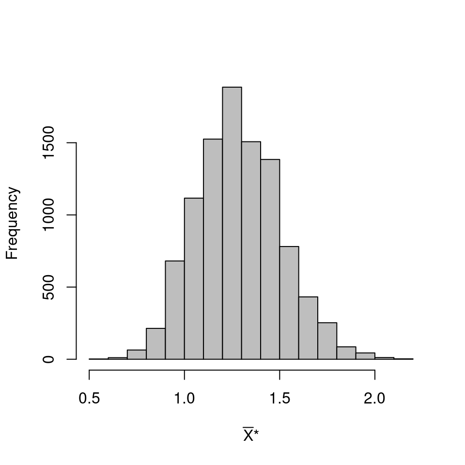

```r
# Using base R with `bsm`
hist(bsm, xlab = substitute(paste(bar(X),"*")), main = "", col = "gray")
```

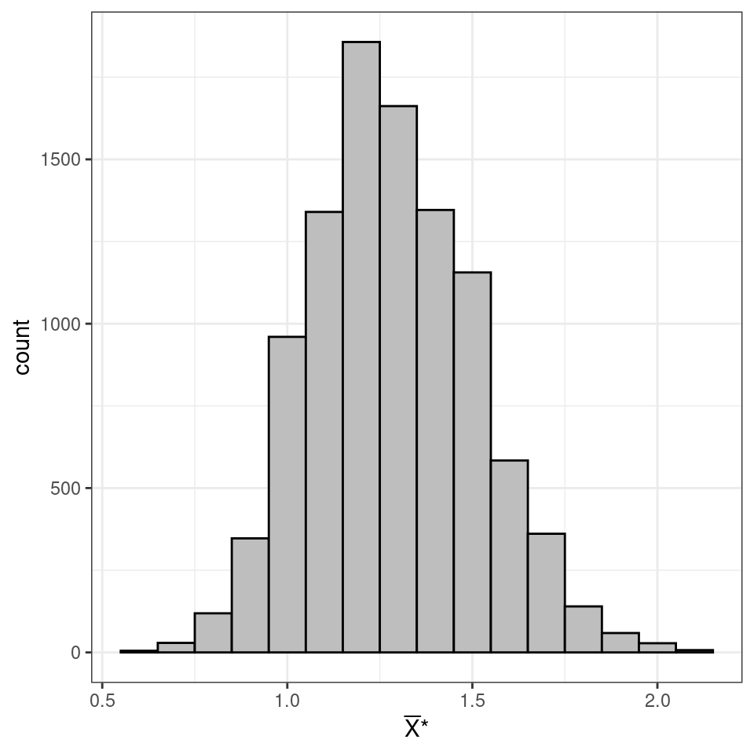

```r
# Using ggplot2 with `bsm`
ggplot(data = data.frame(bsm = bsm), aes(x = bsm)) +
  geom_histogram(binwidth = 0.1, fill = "gray", color = "black") +
  theme_bw() +
  labs(x = substitute(paste(bar(X),"*")))
```

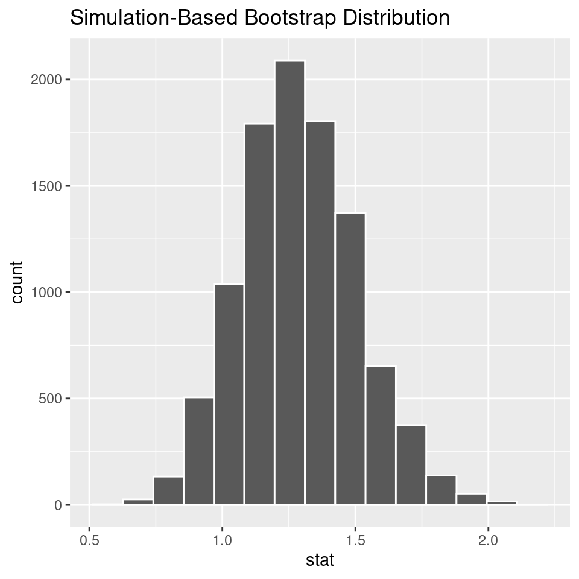

```r
# Using wrapper functions with bsmip (an infer object)
visualize(bsmip)
```

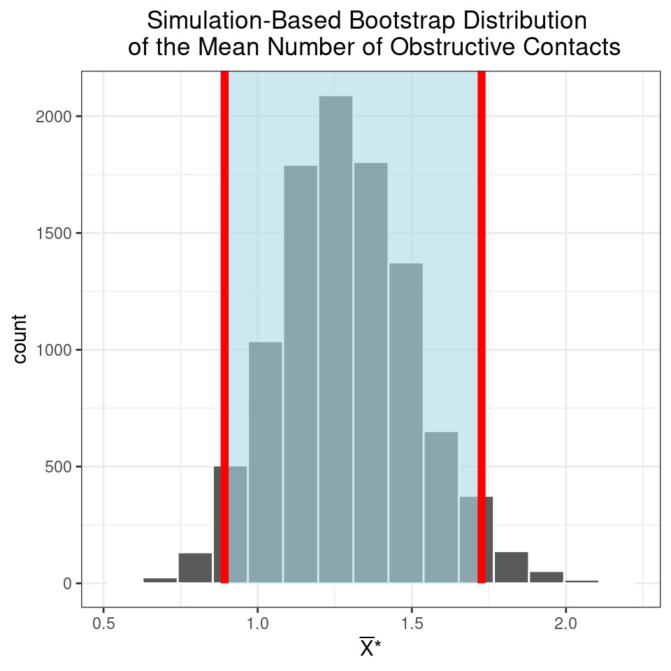

```r
visualize(bsmip, fill = "purple") +
  labs(x = substitute(paste(bar(X),"*")),
       title = "Simulation-Based Bootstrap Distribution \n of the Mean Number of Obstructive Contacts") +
  shade_confidence_interval(CI1, color = "red", fill = "lightblue") +
  theme_bw() +
  theme(plot.title = element_text(hjust = 0.5))
```

3. Create a 98% bootstrap percentile confidence interval for the mean `fat` of males in the `BODYFAT` data set from the `PASWR2` package.

```r
#Creating a vector with the Male fat values
BODYFAT %>%
  filter(sex == "M") %>%
  select(fat) %>%
  pull() -> fat
fat
```

```
[1]  9.5  7.8 17.8 27.4
```

```r
# Another approach using base R
subset(BODYFAT, subset = sex == "M", select = fat, drop = TRUE) -> fat2
fat2
```

```
[1]  9.5  7.8 17.8 27.4
```

```r
# One more approach
BODYFAT$fat[BODYFAT$sex=="M"] -> fat3
fat3
```

```
[1]  9.5  7.8 17.8 27.4
```

```r
B <- 10^4
bsmf <- numeric(B)
for(i in 1:B){
  bss <- sample(fat, size = sum(!is.na(fat)), replace = TRUE)
  bsmf[i] <- mean(bss)
}
(quantile(bsmf, probs = c(0.01, 0.99)) -> BSPCIF)
```

```
    1%    99%
 8.225 25.000
```

```r
# Using infer
BODYFAT %>%
  filter(sex == "M") %>%
  specify(response = fat) %>%
  generate(reps = B, type = "bootstrap") %>%
  calculate(stat = "mean") -> IFM
(get_confidence_interval(IFM, level = 0.98) -> CIF1)
```

```
# A tibble: 1 × 2
  lower_ci upper_ci
     <dbl>    <dbl>
1     8.22       25
```

## 1.2 Visualize the Bootstrap Distribution

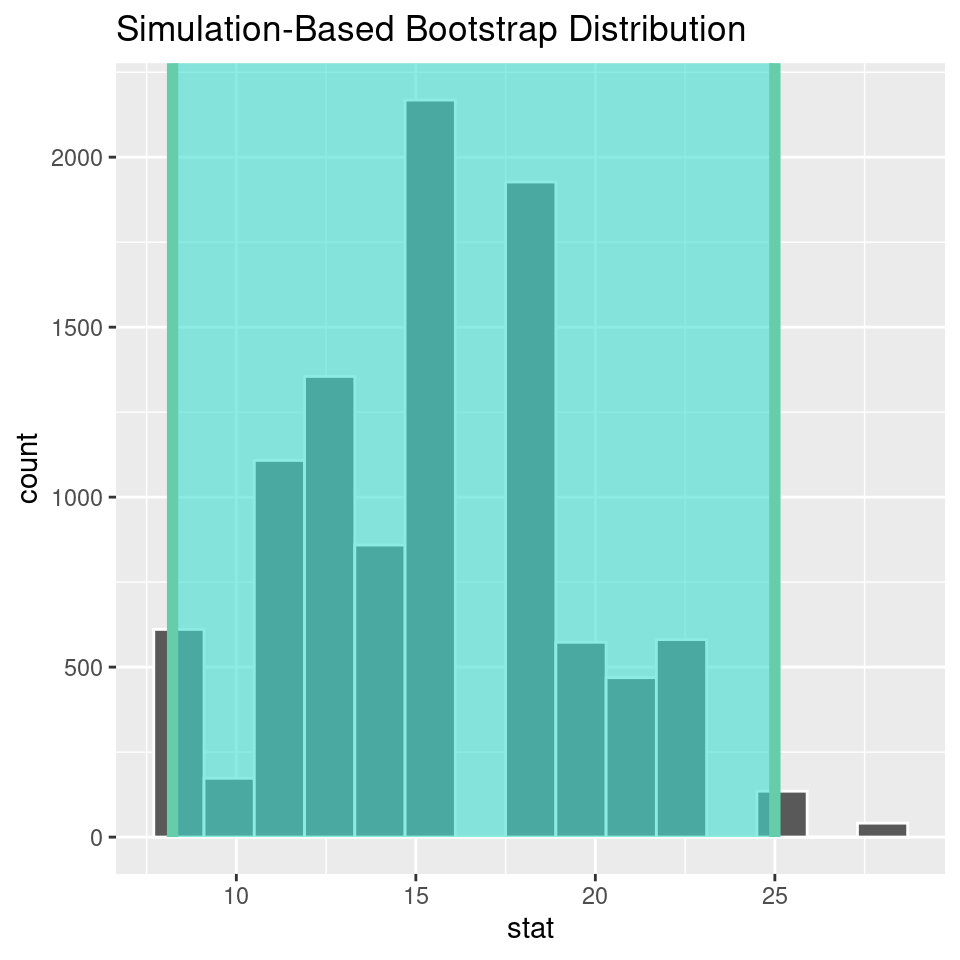

```r
visualize(IFM) +
  shade_confidence_interval(endpoints = CIF1)
```

# 2 Bootsrap Distribution for the Difference of Two Means

4. Construct a 90% bootstrap percentile confidence interval for the difference between the mean obstructive contacts using the hamstring stretch position and the mean obstructive contacts using the traditional sitting position. (Use the `EPIDURAL` data set from `PASWR2`)

```r
EPIDURALC %>%
  filter(treatment == "Hamstring Stretch") %>%
  select(oc)  %>%
  pull() -> ochs # OCs for hamstring stretch
EPIDURALC %>%
  filter(treatment == "Traditional Sitting") %>%
  select(oc) %>%
  pull() -> octs # OCs for traditional sitting
####
B <- 10^4
dm <- numeric(B)
for(i in 1:B){

  bsshs <- sample(ochs, size = sum(!is.na(ochs)), replace = TRUE)
  bssts <- sample(octs, size = sum(!is.na(octs)), replace = TRUE)
  dm[i] <- mean(bsshs) - mean(bssts)
}
(quantile(dm, probs = c(0.05, 0.95)) -> CIDM)
```

```
        5%        95%
-0.3510204  1.2285714
```

**The 90% bootstrap percentile confidence interval for the difference in mean obstructive contacts for the hamstring stretch treatment minus the mean obstructive contacts for the traditional sitting position is: $\text{CI}_{0.90}(\mu_{hs} - \mu _{ts})= [-0.3510204, 1.2285714]$.**

```r
EPIDURALC %>%
  specify(oc ~ treatment) %>%
  generate(reps = B, type = "bootstrap") %>%
  calculate(stat = "diff in means", order = c("Hamstring Stretch", "Traditional Sitting")) -> BSDM
(get_confidence_interval(BSDM, level = 0.90) -> CIDM)
```

```
# A tibble: 1 × 2
  lower_ci upper_ci
     <dbl>    <dbl>
1   -0.355     1.22
```

## 2.1 Visualize the Bootstrap Distribution

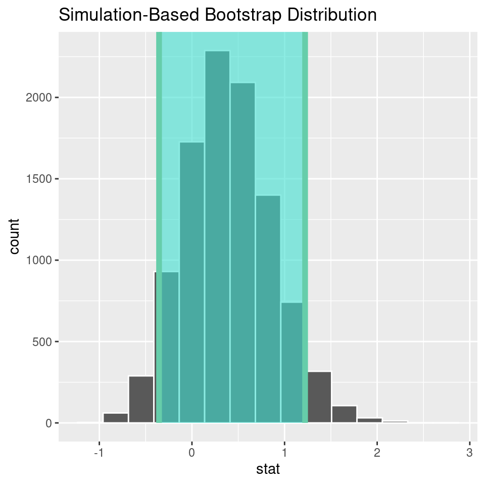

```r
visualize(BSDM) +
  shade_confidence_interval(endpoints = CIDM)
```

# 3 Bootstrap Percentile Confidence Interval for the Proportion

5. Construct a 95% bootstrap percentile confidence interval for the true proportion of women who have no complications while receiving an epidural.

```r
results <- EPIDURAL$complications=="None"
(phat <- mean(EPIDURAL$complications=="None"))
```

```
[1] 0.8941176
```

```r
B <- 10^4
phatbs <- numeric(B)
for(i in 1:B){
  bss <- sample(results, size = sum(!is.na(results)), replace = TRUE)
  phatbs[i] <- mean(bss)
}
(quantile(phatbs, probs = c(0.025, 0.975)) -> CIP)
```

```
     2.5%     97.5%
0.8235294 0.9529412
```

```r
EPIDURAL %>%
  mutate(no_complications = (complications == "None")) %>%
  specify(response = no_complications, success = "TRUE") %>%
  generate(reps = 10^4, type = "bootstrap") %>%
  calculate(stat = "prop") -> PS
get_confidence_interval(PS, level = 0.95)
```

```
# A tibble: 1 × 2
  lower_ci upper_ci
     <dbl>    <dbl>
1    0.824    0.953
```

# 4 Large Sample CI for $p$

```r
(n <- sum(!is.na(results)))
```

```
[1] 85
```

```r
phat*n
```

```
[1] 76
```

```r
(1 - phat)*n
```

```
[1] 9
```

```r
CI <- phat +c(-1, 1)*qnorm(.975)*sqrt(phat*(1-phat)/n)
CI
```

```
[1] 0.8287071 0.9595282
```

```r
# OR
library(binom)
binom.confint(x = 76, n = 85, conf.level = 0.95, methods = "all")
```

```
          method  x  n      mean     lower     upper
1  agresti-coull 76 85 0.8941176 0.8087988 0.9453536
2     asymptotic 76 85 0.8941176 0.8287071 0.9595282
3          bayes 76 85 0.8895349 0.8226871 0.9511168
4        cloglog 76 85 0.8941176 0.8064044 0.9434493
5          exact 76 85 0.8941176 0.8084961 0.9504273
6          logit 76 85 0.8941176 0.8088548 0.9439819
7         probit 76 85 0.8941176 0.8135824 0.9458938
8        profile 76 85 0.8941176 0.8172229 0.9476443
9            lrt 76 85 0.8941176 0.8172260 0.9476675
10     prop.test 76 85 0.8941176 0.8038144 0.9474398
11        wilson 76 85 0.8941176 0.8108648 0.9432876
```

In Class Problem: Use the data `BODYFAT` from `PASWR2` to construct a 95% percentile bootstrap confidence interval for $\mu_{female\_fat} - \mu_{male\_fat}$.